# Infering signaling interactions using RNAMagnet

Lars Velten

2019-01-23

This vignette demonstrates the use of RNAMagnet for infering putative signaling interactinos in the context of data from the bone marrow niche. A second vignette describes the use of RNAMagnet for analyzing cellular co-localization and physical cell-cell interactions.

The idea behind of RNAMagnet is to identify, for each single cell from a dataset, which cell population this cell is particularly likely to interact with. Potential signaling interactions between cells and anchors are scored based on the mutual expression level of ligands and their cognate receptors. We can retrieve the underlying receptor-ligand lists using `getLigandsReceptors`.

```r
require(RNAMagnet)
require(ggplot2)

ligrec <- getLigandsReceptors("1.0.0",cellularCompartment = c("Secreted","Both"),manualAnnotation = "Correct")
head(ligrec)
```

```
##            Pair.Name Ligand.Mouse Receptor.Mouse     Source
## 1           A2m-Lrp1          A2m           Lrp1 Ramilowski
## 3     Adipoq-Adipor1       Adipoq        Adipor1 Ramilowski
## 4     Adipoq-Adipor2       Adipoq        Adipor2 Ramilowski
## 5   Adm-Calcrl&Ramp2          Adm   Calcrl&Ramp2     Baccin
## 8 Angpt1-Itgav&Itgb5       Angpt1    Itgav&Itgb5     Baccin
## 9       Angpt1-Itgb1       Angpt1          Itgb1     Baccin
##   ManualAnnotation Ligand.CC Ligand.GO                  Reference
## 1          Correct  Secreted     Other 1702392,10652313, 12194978
## 3          Correct  Secreted     Other                   12802337
## 4          Correct  Secreted     Other         12802337, 12802330
## 5          Correct  Secreted     Other                   10342881
## 8          Correct  Secreted     Other                   24048525
## 9          Correct  Secreted     Other                   11346644
```

## The data at hand

Let’s familiarize ourselves with the dataset at hand: Our dataset contains 7497 cells from 32 populations and is stored as an object of class **seurat**.

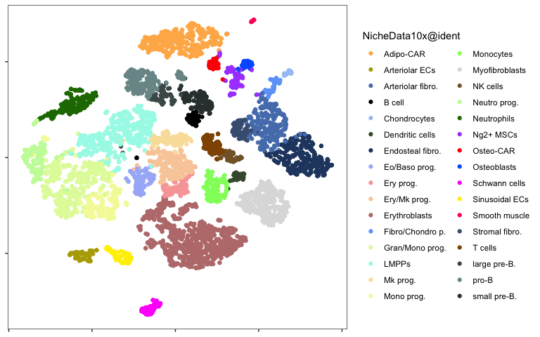

```r
qplot(x = NicheData10x@dr$tsne@cell.embeddings[,1], y = NicheData10x@dr$tsne@cell.embeddings[,2], color =NicheData10x@ident) + scale_color_manual(values = NicheDataColors) + theme_bw() + theme(panel.grid = element_blank(), axis.text = element_blank(), axis.title = element_blank())
```

## Running RNAMagnet for signaling interactions

Simply run `RNAMagnetSignanling`:

```r
  result <- RNAMagnetSignaling(NicheData10x)
```

```
## Setting everything up...
## Now running MAGIC to impute dropout values...
## Now running RNAMagnet...
```

The result is an object of class `rnamagnet`. The `specificty` slot of this object contains a numerical value for each single cell describing the propensity of that cell to receive signals from the 32 different cell types; see `?RNAMagnetBase` for a description of the underlying algorithm. We can plot these data to visualize e.g. the ability of different cells to receive signals from Adipo-CAR cells:

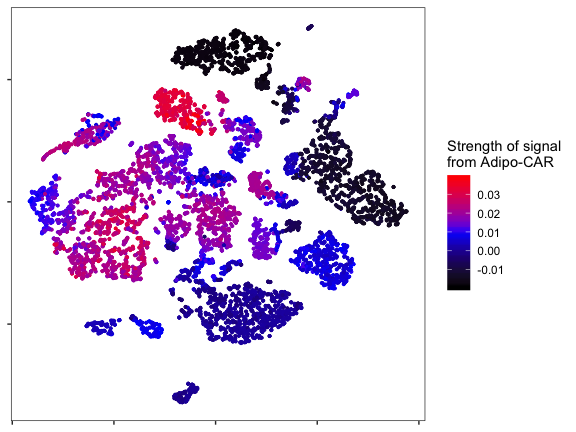

```r
qplot(x =NicheData10x@dr$tsne@cell.embeddings[,1], y=NicheData10x@dr$tsne@cell.embeddings[,2], color = result@specificity[,"Adipo-CAR"] ,size=I(0.75)) + scale_color_gradientn(name = "Strength of signal\nfrom Adipo-CAR",colours = c("black","blue","red")) + theme_bw() + theme(panel.grid = element_blank(), axis.text = element_blank(), axis.title = element_blank())
```

…or we can summarise these scores at the level of cell types, and draw a network representation.

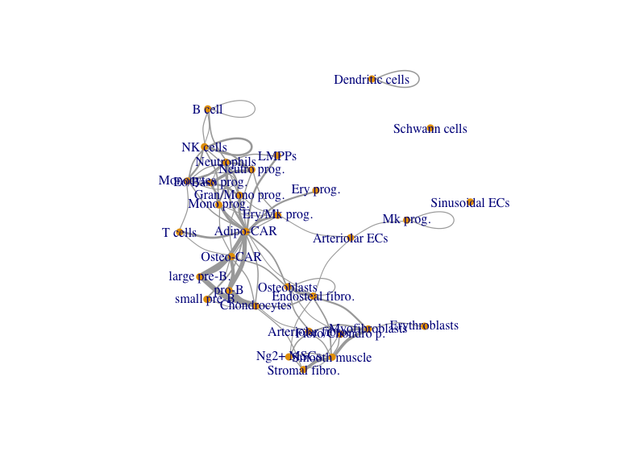

```r
PlotSignalingNetwork(result, threshold = 0.01)
```

To have a closer look at the molecules mediating the interactions, we can use the function `getRNAMagnetGenes`.

```r
getRNAMagnetGenes(result, "Osteo-CAR", "pro-B")
```

```
##          score              pair
## 199 0.89350964        Rspo3-Lgr5
## 197 0.66948412        Rspo2-Lgr5
## 148 0.62661641          Il7-Il7r
## 155 0.40731788         Kng2-Cd93
## 147 0.36234436         Il7-Il2rg
## 142 0.31755391         Il2-Il2rg
## 3   0.24222871    Adipoq-Adipor2
## 131 0.22610108        Il15-Il2rg
## 77  0.18556897      Cxcl12-Cxcr4
## 212 0.14930568        Sfrp1-Fzd6
## 270 0.14903326         Wnt4-Fzd6
## 2   0.12251685    Adipoq-Adipor1
## 128 0.11380617       Igfbp4-Lrp6
## 153 0.09101410          Kitl-Kit
## 72  0.08665269         Ctgf-Lrp6
## 200 0.08231748        Rspo3-Sdc4
## 162 0.08032150          Mdk-Sdc4
## 78  0.07646644       Cxcl12-Sdc4
## 121 0.07443371 Hspg2-Itga2&Itgb1
## 275 0.07333014        Wnt5a-Fzd6
## 236 0.06236368      Tgfb3-Tgfbr1
## 278 0.05575469        Wnt5a-Lrp6
## 30  0.05105769       Bmp4-Acvr2a
```